# report

## **1. Introduction**

### **1.1 Motivation**

Professional golf has gone through a tremendous evolution over the past 20 years. Technical development in equipment, training method, and analytics have transformed the sport closer to a data driven decision making process, rather than feeling and muscle memory. Many may wonder: **What actually drives performance on the PGA Tour?**

Most amateur golfers often focus on distance, consistency, and precision without an accurate measure. However, data from PGA Tour suggest some more complex metrics. The stroke gain (SG) is **a golf statistic that shows how many strokes you gained or lost on any given shot compared to an average player during your round of golf.**

This project analyzes PGA Tour player performance from 2007 to 2022, by combining two publicly available professional datasets into an integrated dataframe. The goal is to use data analysis tools to answer key performance questions and unveil how modern professional golf has evolved.

### **1.2 Research Questions**

> 1. How have key PGA Tour metrics (driving distance, SG metrics) evolved from 2007–2022?
> 2. Are there identifiable types of PGA Tour players using unsupervised learning?
> 3. Which performance metrics best predict scoring average on the PGA Tour?
> 4. What distinguishes winning players from the rest of the field?
> 5. Is modern success driven more by strokes gained tee-to-green or putting
> 6. Does distance directly contributes to better score or titles won when compared to stroke gain metrics?

# **2. Data Summary**

### **2.1 Dataset Description**

The dataset used for this project merges two separate PGA Tour season-level datasets spanning **2007–2022**. After cleaning and standardization, the unified dataframe contains:

> - **Player name**
> - **Year**
> - **Driving distance (yards)**
> - **Greens in regulation (%)**
> - **Scoring average (Strokes)**
> - **Strokes gained metrics: (Strokes)**
>   - SG_P (putting)
>   - SG_TTG (tee-to-green)
>   - SG_T (total)
> - **Top-10 finishes**
> - **Wins**
> - **Country**

This dataset is well suited for analyzing:

- Long-term performance trends
- Relationships among core performance variables
- Performance segmentation
- Predictive modeling of scoring

# **3. Exploratory Data Analysis**

**Introduction to Exploratory Data Analysis**

Research question:

> How have key PGA Tour performance metrics evolved from 2007-2022?

To better answer the question, this section will explore the distribution and trends of several key metrics, including scoring average, driving distance, and stroke gain metrics. Each subsections below focuses on a specific metric and analyzes how its distribution changes over time through data visualization methods.

### **3.1 Trend in Scoring Average Over Time**

Scoring average shows a gradual decline in the 15-year period, from 70.94-70.64. This suggest:

- Improvements in player fitness
- Equipment advancement
- Stronger analytically and systematic training method

Even small improvements in PGA scoring average are significant in the given competitiveness of the PGA Tour.

### **3.2 Driving Distance Over Time**

Driving distance shows a clear upward trend, reflecting the “distance boom” widely discussed in professional golf. Nowadays, player focus more on weight/functional training, faster swing speed, and optimal launch angle and all these factor contributes to the long drives today.

However, distance itself is only a small section of the golf game, and there is no guarantee that longer distance leads to more wins. Therefore, it leads to another question:

> Does distance directly contributes to better score or titles won when compared to stroke gain metrics?

This question will be address later in the predictive model section.

### **3.3 Relationship Between SG Metrics and Scoring**

Correlations between scoring and strokes gained show:

- **SG_TTG is the strongest predictor of low scoring**
- **SG_T also strongly relates to performance**
- **SG_P contributes meaningfully but not as dominantly as SG_TTG**

  This supports findings from Broadie (2011), who showed that the long game (approach + driving) explains most of the variation in scoring among PGA players.

### **4. Unsupervised Learning — Player Segmentation**

### **4.1 Purpose**

- The distribution of scoring averages narrows over time, indicating a more competitive field. Usually in a more competitive industry, player will create their own unique route to success, forming different types of player with specific characteristics. In this section, unsupervised learning was used to identify player groups based on performance metrics. After standardization, K mean = 4 was able to provide valid and significant clusters.
- Research Question:

  > Are there identifiable types of PGA Tour players using unsupervised learning?

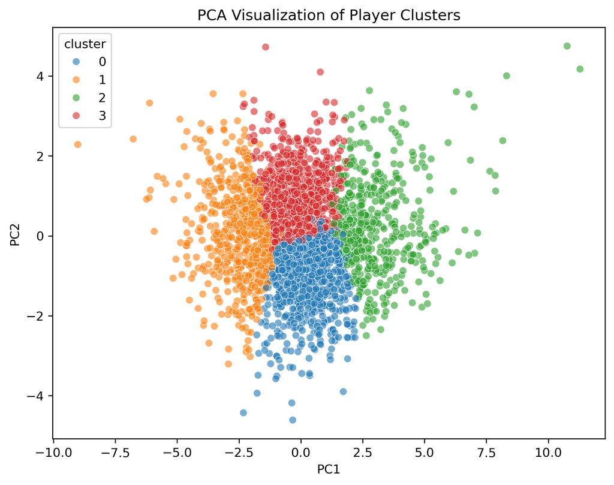

**Cluster 0 - Balanced Professionals**

- Average SG metrics
- Solid but not outstanding in any single category
- Mid-level scoring average
- Represents the average players on tour, such as Anthony Kim, Jeff Overton, Kenny Perry

**Cluster 1 - Struggling Players**

- Negative SG_TTG and SG_T
- Higher scoring average
- Few top-10 finishes
- Reflecting players who struggles to keep their tour status, such as Anders Hanson, Glen Day, Gavin Coles

**Cluster 2 - Elite Ball Strikers**

- Highest SG_TTG
- Lowest scoring average
- Best combination of GIR%, distance, and SG_TTG
- Most number of wins and top-10s
- Represents the top tier player on tour, such as Tiger Woods, Ernie Els, Justin Rose

**Cluster 3 - Elite Putters**

- Highest SG_P
- Moderate SG_TTG
- Relies heavily on short-game performance
- Represents the great putters on tour, such as Arron Oborholser, Padraig Harrington, Tim Clark

### **4.2 Key Insight**

These clusters showcase the competitiveness of PGA tour, and suggesting there is no single path to success. While SG_TTG seems to be the biggest driver of elite performance, players can still compensate through specialization in driving distance, putting or other areas. By understanding the player profiles, we are able to better guide professional golfers with self evaluation, training priorities and performance forecasting.

# **5. Supervised Learning**

### **5.1 Goal**

Research questions:

> 1. Which performance metrics best predict scoring average on the PGA Tour?
> 2. What distinguishes winning players from the rest of the field?
> 3. Is modern success driven more by strokes gained tee-to-green or putting
> 4. Does distance directly contributes to better score or titles won when compared to stroke gain metrics?

### **5.2 Scoring Average Prediction (Regression)**

To model scoring average, four key performance features were selected:

- **Driving Distance**
- **Greens in Regulation % (GIR%)**
- **Strokes Gained Putting (SG_P)**
- **Strokes Gained Tee-to-Green (SG_TTG)**

These metrics corresponds to the three major categories of golf performance: distance, accuracy/ball striking, and putting.

The dataset was split into training and testing sets (80/20), and models were evaluated using **RMSE** and **R²**.

### **Model Performance**

| Model | RMSE | **R²** |
| --- | --- | --- |
| Linear Regression | 0.192 | 0.910 |
| Random Forest Regression | 0.206 | 0.896 |

### **Interpretation**

The linear regression model’s strong performance indicates that **scoring average is highly predictable using only four metrics**. An R² of **0.91** means the model explains **91% of the variation** in scoring averages across 2,700+ player-seasons.

Random Forest, despite being more flexible, performed slightly worse, suggesting that **the scoring determinants behave in a mostly linear fashion**, consistent with sports analytics literature.

### **Feature Importance**

The Random Forest model provides a clear ranking:

1. **SG_TTG (0.726)**
2. **SG_P (0.234)**
3. **GIR% (0.021)**
4. **Driving Distance (0.019)**

**Key Takeaways**

> **Tee-to-green stroke gain performance is the major factor of low scoring average on PGA Tour**

> **Strokes gained tee-to-green is a much stronger factor in modern PGA Tour success comparing to stroke gain putting**

> **Driving distance does not have a strong correlation with low scoring average on PGA Tour**

This aligns with Broadie (2011), who demonstrated that differences in long-game performance explain most scoring separation among professionals.

### **5.3 Predicting Season Wins (Classification)**

To model **whether a player wins at least one event**, the same four metrics were used.

A binary variable was created to classify the groups:

**has_win = 1 if win > 0**

**has_win = 0 otherwise**

### **Model Performance**

| Model | Accuracy | ROC-AUC |
| --- | --- | --- |
| Logical Regression | 0.882 | 0.768 |
| Random Forest Classifier | 0.880 | 0.710 |

Interpretation

Although both models have high accuracy, the models struggle to correctly identify winners:

- Logistic Regression recall for winners = 0.04
- Random Forest recall for winners = 0.10

This suggests that winning on PGA Tour is extremely difficult and fluctuating, because there are far more unconsidered factors beyond selected variables, such as course style, weather condition, and even luck.

Feature Importance for Wins

1. **SG_TTG (0.299)**
2. **GIR% (0.240)**
3. **Driving Distance (0.231)**
4. **Putting (0.230)**

**Key Takeaway**

> **Winning requires a complete golf game, its very unlikely that player only reply on one part of the game to win.**

# **6. Conclusions**

### **6.1 Key Takeaways**

This project set out to understand how PGA Tour player performance has evolved over time and which performance metrics most strongly distinguish elite players from the rest of the field. Using a combined dataset spanning 2007–2022, the analysis incorporated exploratory data visualization, unsupervised clustering, and supervised predictive modeling to uncover systematic trends in modern professional golf.

**Key Findings**

1. **Scoring averages have gradually declined over the past 15 years**, supported by simultaneous rises in driving distance and improvements in strokes gained metrics. This reflects advancements in athletic training, analytics-driven coaching, and equipment technology. Even small reductions in scoring average indicate increased competitiveness on the PGA Tour.
2. **Player archetypes have become more distinct.**  
   K-means clustering revealed four meaningful groups—balanced professionals, struggling players, elite ball-strikers, and elite putters. These clusters align with real observed playing styles on tour and demonstrate how players succeed using different combinations of strengths. The presence of Tiger Woods, Ernie Els, and Justin Rose in the “Elite Ball-Striker” cluster further validates the segmentation.
3. **Tee-to-green performance is the strongest predictor of scoring.**  
   Both linear regression (R² ≈ 0.91) and random forest modeling confirmed that **SG_TTG is the dominant factor in explaining scoring average**, far exceeding putting, distance, or GIR%. This supports existing literature (e.g., Broadie, 2011) emphasizing the importance of the long game in professional golf.
4. **Winning is difficult to predict, but certain patterns emerge.**  
   Predictive models for win probability showed lower performance due to class imbalance (only ~12% of players win in a given season). However:
   - SG_TTG again emerged as the strongest predictor of winning.
   - Distance and SG_P contributed meaningfully but were secondary.

     The insight is clear: **consistent ball-striking is the foundation of winning**, while putting helps differentiate players *within* tournaments.
5. **Distance alone does not explain success**, despite its upward trend. Players are hitting farther than ever, but distance without strong tee-to-green proficiency does not reliably predict low scoring or wins. This reinforces that modern distance gains matter most when paired with elite approach and accuracy skills.

**Overall Conclusion**

Modern PGA Tour success is built primarily on **tee-to-green excellence**, supported by increased athleticism and technology. While putting and driving distance certainly contribute, the underlying determinant of elite performance remains the ability to consistently gain strokes through approach play and long-game precision. The narrowing distribution of scoring averages and the emergence of clear performance archetypes reflect a professional landscape that is deeper, more competitive, and more analytically optimized than ever before.

This project demonstrates how statistical modeling and machine learning can reveal meaningful structure in sports performance data, and it highlights clear opportunities for future research—such as incorporating shot-level data, modeling year-to-year player progression, or quantifying the influence of course difficulty and weather conditions.

### **6.2 Limitations**

**Class Imbalance**

Only **337 out of 2,747** player-seasons included a win.

This imbalance makes accurate prediction challenging because winning is a rare event even for elite players.

Short, non-technical:

- Missing years (2023–2025)
- No shot-level granularity
- Some players have sparse year-to-year data
- Combined dataset required manual alignment